# STAT 240: Airport Case Study

# Read in Data

- We can now read in the data from six different airports and combine into a single data set
- Here, we do this with one line for each data set and then use `bind_rows()` to combine them.
- Then, we can delete the temporary files

```r
den = read_csv("../../data/DEN-2018.csv")
jfk = read_csv("../../data/JFK-2018.csv")
lax = read_csv("../../data/LAX-2018.csv")
msp = read_csv("../../data/MSP-2018.csv")
ord = read_csv("../../data/ORD-2018.csv")
sfo = read_csv("../../data/SFO-2018.csv")

awt = bind_rows(den, jfk, lax, msp, ord, sfo)
# awt is at the airport-day-hour level

rm(den, jfk, lax, msp, ord, sfo)
# rm standing for "remove", deletes the objects we no longer need to free up some computer memory
```

# Passengers by Terminal

> How many passengers and flights went through each airport-terminal combination (in 2018)? Display this in a summary table, with all the terminals from the most popular airports displayed first, and the next most popular airport’s terminals shown second, and so on - with terminals sorted within airport by their number of passengers.
- Note that the `all_total` column represents total passengers within that terminal-day-hour, and `all_flights` represents total flights within that terminal-day-hour. We will need to summarize these columns to the level of airport-terminal.
- Then, **add a column** `total_airport_passengers` which includes the total number of passengers in the corresponding airport across all terminals. *(Note: this column will repeat values for airports with multiple terminals.)*
- Arrange the table by descending order of `total_airport_passengers` (this will sort the airports by most to least international flights) and then break ties by the total number of passengers in that terminal.
- Remove `total_airport_passengers` and print the table.

```r
## airports and terminals
awt %>%
  group_by(airport, terminal) %>%
  summarize(passengers = sum(all_total),
            flights = sum(all_flights)) %>%
  group_by(airport) %>%
  mutate(total_airport_passengers = sum(passengers)) %>%
  arrange(desc(total_airport_passengers), desc(passengers)) %>%
  select(-total_airport_passengers)
```

```
## # A tibble: 16 × 4
## # Groups:   airport [6]
##    airport terminal                           passengers flights
##    <chr>   <chr>                                   <dbl>   <dbl>
##  1 JFK     Terminal 4 (IAT)                      6606351   32839
##  2 JFK     Terminal 1                            3863833   14522
##  3 JFK     Terminal 8 (American)                 1996535    9628
##  4 JFK     Terminal 7 (British)                  1750517    8536
##  5 JFK     Terminal 5 (Jet Blue)                 1605432   10638
##  6 LAX     Tom Bradley International Terminal    9801130   45055
##  7 LAX     Satellite 2                            796057    6539
##  8 LAX     Satellite 7                            770716    5958
##  9 LAX     Terminal 4                             353672    2925
## 10 LAX     Satellite 5                              5357     527
## 11 SFO     Terminal G                            3501690   15480
## 12 SFO     Terminal A                            2744262   11975
## 13 ORD     Terminal 5                            5601907   29529
## 14 DEN     International                         1032579    5815
## 15 MSP     Terminal 1Lindbergh                    757179    4533
## 16 MSP     Terminal 2Humphrey                     243953    4567
```

```r
### JFK and LAX have five different international terminals
### The other airports have one or two each.
```

# Days of Data

> How many unique days of data are there for each airport?
- Problem: We can’t just count how many times each airport occurs; because different airports have different numbers of terminals, and each terminal might not necessarily have data for every day-hour.

```r
awt %>%
  count(airport)
```

```
## # A tibble: 6 × 2
##   airport     n
##   <chr>   <int>
## 1 DEN      2888
## 2 JFK     28594
## 3 LAX     16709
## 4 MSP      5793
## 5 ORD      7008
## 6 SFO     11097
```

```r
## examine date by airport
awt %>%
  group_by(airport, date) %>%
  summarize() %>% # A shortcut for group_by(airport, date) %>% summarize() is distinct(group_by, summarize)
  group_by(airport) %>%
  summarize(n = n())
```

```
## # A tibble: 6 × 2
##   airport     n
##   <chr>   <int>
## 1 DEN       364
## 2 JFK       364
## 3 LAX       364
## 4 MSP       364
## 5 ORD       364
## 6 SFO       364
```

```r
## One date is missing for all the airports
```

# Which Date is Missing?

> Identify which date is missing for each airport; is it the same day for each airport?
- One day is missing for each airport! Can we figure out which one it is?
- One approach could be to narrow down by:
  - adding a month variable
  - counting the number of distinct days within each month
  - seeing which total is less than the actual number of days
  - find the distinct days within that month
- But a more straightforward way as we did with the Madison weather data is to:
  - create a mini data frame with all possible dates
  - join with a data summary of the dates and terminals in the data set
  - see what is missing

```r
all_dates = tibble(
  date = seq(ymd("2018-01-01"), ymd("2018-12-31"), 1)
)

airport_dates = awt %>% distinct(airport, date) # returns all the unique combinations of airport & date which appear in awt

# return all the dates which appear in all_dates that don't appear in airport_dates
anti_join(all_dates, airport_dates)
```

```
## # A tibble: 1 × 1
##   date
##   <date>
## 1 2018-05-08
```

```r
# Here's how you can manually verify it is the same missing date for each airport; the "rep" command stands for "replicate" or "repeat". We are creating a dataframe with 365*6 rows, one row for each airport-day combination.

## Create a mini temporary data set with all dates in 2018 for each airport code
temp1 = tibble(
  date = rep(seq(ymd("2018-01-01"), ymd("2018-12-31"), 1), times = 6),
  airport = rep(c("DEN", "JFK", "LAX", "MSP", "ORD", "SFO"), each = 365)
)

## Create another temporary data set with the actual dates and airports in awt

temp2 = awt %>%
  select(airport, date) %>%
  distinct()

## Use anti_join() to find rows in temp1 not in temp2
temp1 %>%
  anti_join(temp2)
```

```
## # A tibble: 6 × 2
##   date       airport
##   <date>     <chr>
## 1 2018-05-08 DEN
## 2 2018-05-08 JFK
## 3 2018-05-08 LAX
## 4 2018-05-08 MSP
## 5 2018-05-08 ORD
## 6 2018-05-08 SFO
```

- We see that May 8, 2018, is missing from each airport. Curious!
- Verify this

```r
## check on May 8
awt %>%
  filter(date == "2018-05-08")
```

```
## # A tibble: 0 × 21
## # ℹ 21 variables: airport <chr>, terminal <chr>, date <date>, hour <chr>,
## #   us_avg_wait <dbl>, us_max_wait <dbl>, non_us_avg_wait <dbl>,
## #   non_us_max_wait <dbl>, all_avg_wait <dbl>, all_max_wait <dbl>,
## #   all_n_0_15 <dbl>, all_n_16_30 <dbl>, all_n_31_45 <dbl>, all_n_46_60 <dbl>,
## #   all_n_61_90 <dbl>, all_n_91_120 <dbl>, all_n_120_plus <dbl>,
## #   all_excluded <dbl>, all_total <dbl>, all_flights <dbl>, all_booths <dbl>
```

```r
### No airports have any data on May 8, 2018.
```

# Checking Totals

> Does the `all_total` variable match the sum of the other columns of passenger counts?
- Add a column named `check_total` with the sum of the columns which names begin with “all” (except for `all_total`)
- Compare these totals with that in `all_total`
- Filter `awt` to produce a dataframe with the rows where `check_total`, the manually computed total, does not match `all_total`, the given values.

```r
## check that all_total column matches
awt = awt %>%
  mutate(check_total = all_n_0_15 +
            all_n_16_30 +
            all_n_31_45 +
            all_n_46_60 +
            all_n_61_90 +
            all_n_91_120 +
            all_n_120_plus +
            all_excluded)

table_mismatch = awt %>%
  filter(all_total != check_total)
table_mismatch
```

```
## # A tibble: 44 × 22
##    airport terminal     date       hour  us_avg_wait us_max_wait non_us_avg_wait
##    <chr>   <chr>        <date>     <chr>       <dbl>       <dbl>           <dbl>
##  1 JFK     Terminal 1   2018-04-14 0000…          16          86              32
##  2 JFK     Terminal 1   2018-04-15 0000…          10          33              28
##  3 JFK     Terminal 8 … 2018-04-17 0000…           5          21              14
##  4 JFK     Terminal 4 … 2018-04-18 0000…          22         121              81
##  5 JFK     Terminal 7 … 2018-04-18 0000…           7          16               8
##  6 JFK     Terminal 4 … 2018-07-20 0000…          14          86              39
##  7 JFK     Terminal 8 … 2018-07-31 0000…           6          27              13
##  8 JFK     Terminal 4 … 2018-08-04 0000…          19         161              62
##  9 JFK     Terminal 8 … 2018-08-04 0000…           4          22              18
## 10 JFK     Terminal 8 … 2018-08-24 0000…           4          23              18
## # ℹ 34 more rows
## # ℹ 15 more variables: non_us_max_wait <dbl>, all_avg_wait <dbl>,
## #   all_max_wait <dbl>, all_n_0_15 <dbl>, all_n_16_30 <dbl>, all_n_31_45 <dbl>,
## #   all_n_46_60 <dbl>, all_n_61_90 <dbl>, all_n_91_120 <dbl>,
## #   all_n_120_plus <dbl>, all_excluded <dbl>, all_total <dbl>,
## #   all_flights <dbl>, all_booths <dbl>, check_total <dbl>
```

- There are 44 rows where the totals do not match

# Investigating Mismatches

> At what time of day and at which airports are these mismatches happening?

```r
# Recall: We could have done this with count(airport, hour)
table_mismatch %>%
  group_by(airport, hour) %>%
  summarize(n = n())
```

```
## # A tibble: 4 × 3
## # Groups:   airport [4]
##   airport hour            n
##   <chr>   <chr>       <int>
## 1 JFK     0000 - 0100    15
## 2 LAX     0000 - 0100    25
## 3 MSP     0000 - 0100     2
## 4 ORD     0000 - 0100     2
```

```r
### All mismatches are between midnight and 1am.
### Most are at LAX and JFK
```

> Create a histogram to show the distribution of the size of these mismatches.

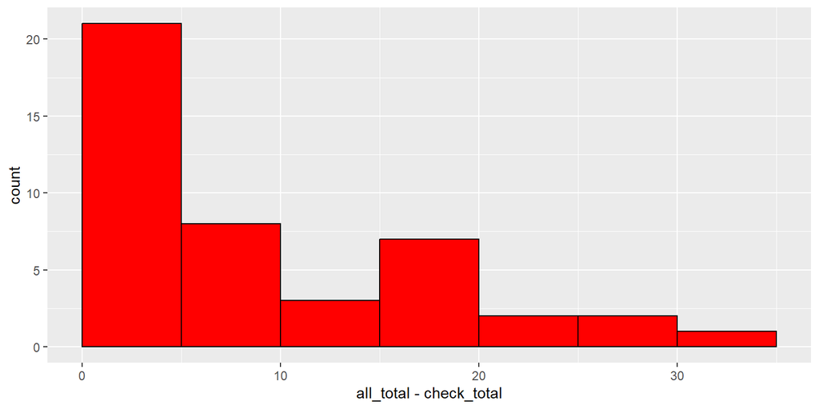

```r
ggplot(table_mismatch, aes(x = all_total - check_total)) +
  geom_histogram(boundary=0, binwidth=5, fill = "red", color = "black")
```

# Busy Months

> Are some months busier than others?
- Begin by adding a month variable and then reordering the columns
- Also add day and weekday for future use

```r
awt = awt %>%
  mutate(month = month(date, label = TRUE),
         day = day(date),
         wday = wday(date, label = TRUE)) %>%
  relocate(month, day, wday, .after = hour)
```

- Total the number of passengers by month and sort by that total, descending.

```r
awt %>%
  group_by(month) %>%
  summarize(total = sum(all_total)) %>%
  arrange(desc(total))
```

```
## # A tibble: 12 × 2
##    month   total
##    <ord>   <dbl>
##  1 Jul   4313581
##  2 Aug   4244065
##  3 Jun   3737710
##  4 Sep   3510723
##  5 Apr   3475220
##  6 Oct   3393282
##  7 Mar   3356425
##  8 May   3337989
##  9 Jan   3249648
## 10 Dec   3145717
## 11 Nov   3020660
## 12 Feb   2646150
```

- The previous summary is affected by different numbers of days in each month.
  - A better solution calculates an average number of daily passengers separately for each month
- Calculate the average daily rate of passengers by month.
- (Recall that May has only 30 observations.)
- Key idea here is to:
  - first summarize by date (and month and day):
  - sum to get daily totals across airport, hours, and terminal
  - then group by month
  - calculate means within the month

```r
busy_months = awt %>%
  group_by(date, month, day) %>%
  summarize(total = sum(all_total)) %>%
  group_by(month) %>%
  summarize(n = n(), total = sum(total)) %>%
  mutate(daily = total/n) %>%
  arrange(desc(daily))

busy_months
```

```
## # A tibble: 12 × 4
##    month     n   total   daily
##    <ord> <int>   <dbl>   <dbl>
##  1 Jul      31 4313581 139148.
##  2 Aug      31 4244065 136905.
##  3 Jun      30 3737710 124590.
##  4 Sep      30 3510723 117024.
##  5 Apr      30 3475220 115841.
##  6 May      30 3337989 111266.
##  7 Oct      31 3393282 109461.
##  8 Mar      31 3356425 108272.
##  9 Jan      31 3249648 104827.
## 10 Dec      31 3145717 101475.
## 11 Nov      30 3020660 100689.
## 12 Feb      28 2646150  94505.
```

> Display these average daily passengers by month in a bar graph.

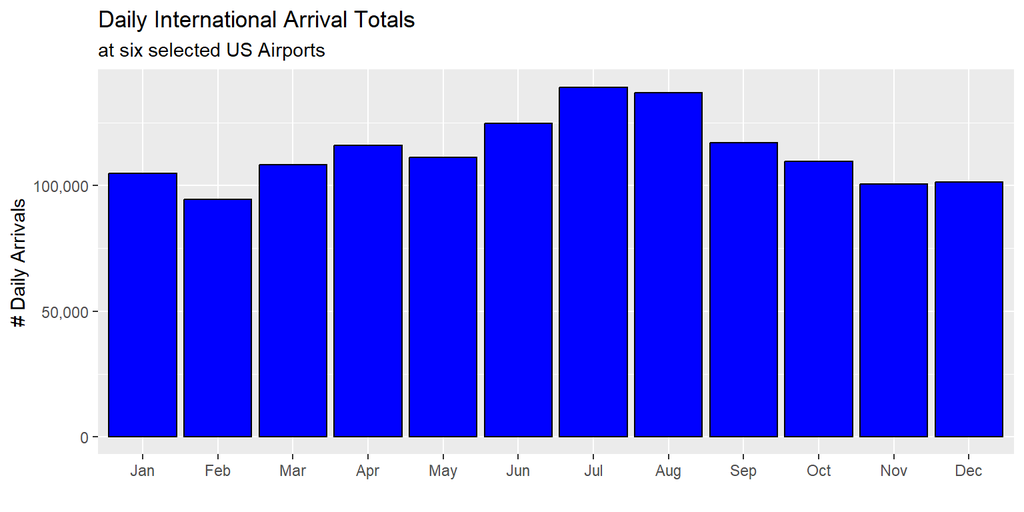

```r
ggplot(busy_months, aes(x=month, y=daily)) +
  geom_col(fill = "blue", color = "black") +
  scale_y_continuous(labels = scales::comma) +
  xlab("") +
  ylab("# Daily Arrivals") +
  ggtitle("Daily International Arrival Totals", subtitle = "at six selected US Airports")
```

- It looks like the summer months (July, August, June) are the busiest in terms of number of passengers traveling per day for the airports in our data.

# Busy Weekdays

> Are some days of the week busier than others?

```r
busy_wdays = awt %>%
  group_by(date, wday) %>%
  summarize(total = sum(all_total)) %>%
  group_by(wday) %>%
  summarize(n=n(), total = sum(total))  %>%
  mutate(daily=total/n) %>%
  arrange(desc(daily))

busy_wdays
```

```
## # A tibble: 7 × 4
##   wday      n   total   daily
##   <ord> <int>   <dbl>   <dbl>
## 1 Sat      52 6544126 125849.
## 2 Sun      52 6366261 122428.
## 3 Mon      53 6121230 115495.
## 4 Fri      52 5833805 112189.
## 5 Thu      52 5628670 108244.
## 6 Wed      52 5532535 106395.
## 7 Tue      51 5404543 105971.
```

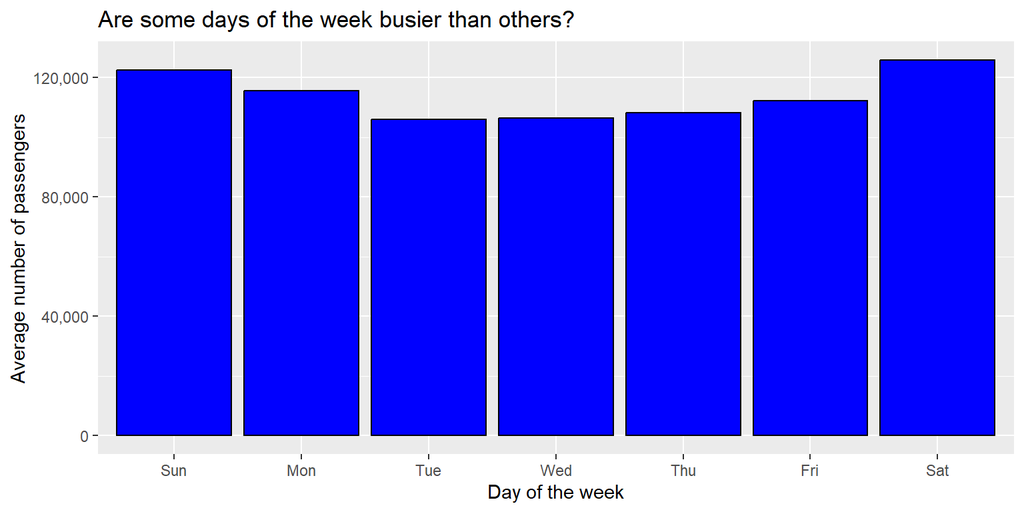

```r
ggplot(busy_wdays, aes(x = wday, y = daily)) +
  geom_col(fill = "blue", color = "black") +
  scale_y_continuous(labels = scales::comma) +
  xlab("Day of the week") +
  ylab("Average number of passengers") +
  ggtitle("Are some days of the week busier than others?")
```

# Busy Times of the Day

> Are some times during the day busier than others?

```r
busy_times = awt %>%
  group_by(date, hour) %>%
  summarize(total = sum(all_total)) %>%
  group_by(hour) %>%
  summarize(n = n(), total = sum(total))  %>%
  mutate(hourly = round(total/n,2)) %>%
  arrange(desc(hourly))
busy_times
```

```
## # A tibble: 24 × 4
##    hour            n   total hourly
##    <chr>       <int>   <dbl>  <dbl>
##  1 1300 - 1400   364 3378614  9282.
##  2 1400 - 1500   364 3187415  8757.
##  3 1500 - 1600   364 3177401  8729.
##  4 1200 - 1300   364 3092218  8495.
##  5 1600 - 1700   364 3043461  8361.
##  6 1700 - 1800   364 2913956  8005.
##  7 1800 - 1900   364 2799314  7690.
##  8 1900 - 2000   364 2700282  7418.
##  9 1100 - 1200   364 2165588  5949.
## 10 2000 - 2100   364 2001425  5498.
## # ℹ 14 more rows
```

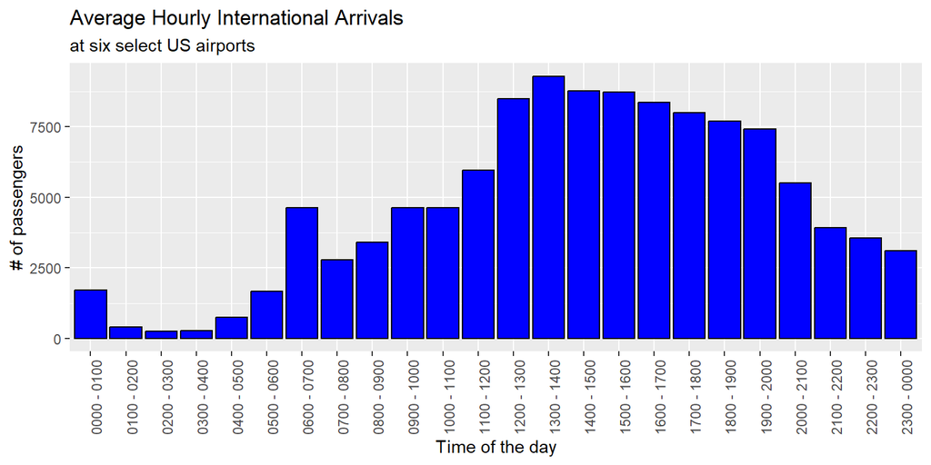

```r
ggplot(busy_times, aes(x = hour, y = hourly)) +
  geom_col(fill = "blue", col = "black") +
  theme(axis.text.x = element_text(angle = 90, hjust = 1))  +
  xlab("Time of the day") +
  ylab("# of passengers") +
  ggtitle("Average Hourly International Arrivals", subtitle = "at six select US airports")
```

# Airport Efficiency

## By Wait Time

> Are some airports more efficient than others in terms of average wait time? Show the distribution of each airport’s `all_avg_wait` times with a boxplot.

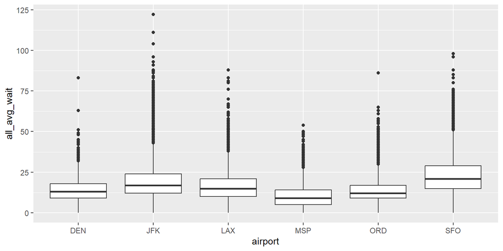

```r
ggplot(awt, aes(x=airport, y=all_avg_wait)) +
  geom_boxplot()
```

- We can adjust the plot by reordering the airports in order by the median of their average waiting time for all passengers.
- We also add better axis labels

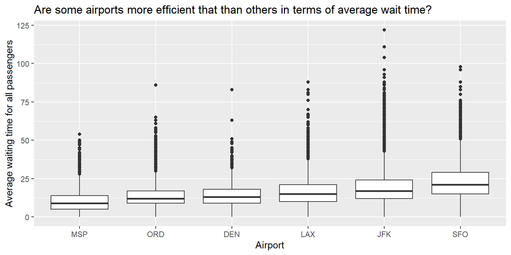

```r
awt = awt %>%
  mutate(airport = reorder(airport, all_avg_wait, FUN=median))
## treat airport as a factor with levels ordered according to the median of the all_avg_wait variable

ggplot(awt, aes(x=airport, y=all_avg_wait)) +
  geom_boxplot() +
  xlab("Airport") +
  ylab("Average waiting time for all passengers") +
  ggtitle("Are some airports more efficient that than others in terms of average wait time?")
```

- Passengers tend to wait longer on average at San Francisco’s airport than the others in this analysis.

> What is the average waiting time at each airport for all passengers?
- To calculate this statistic, we need to sum the waiting times for all passengers and divided by the total number of passengers
- Note that it is incorrect to calculate the average for each airport/terminal/date/hour and then average these values as the number of passengers in each row is different.
  - We want to average by passenger, not by row in the data set
- The strategy is to calculate the total time by all passengers in each row
  - This is the average time multiplied by the number of passengers
- Then, sum times and passengers by airport and divide

```r
awt = awt %>%
  mutate(total_time = all_total * all_avg_wait)

prob_2 = awt %>%
  group_by(airport) %>%
  summarize(avg_wait = sum(total_time) / sum(all_total))

prob_2 %>%
  arrange(avg_wait)
```

```
## # A tibble: 6 × 2
##   airport avg_wait
##   <fct>      <dbl>
## 1 MSP         15.1
## 2 DEN         15.9
## 3 ORD         16.4
## 4 LAX         19.0
## 5 JFK         21.0
## 6 SFO         25.4
```

- Looks like San Francisco is slower than the other airports

## By Passengers Processed Per Booth

> Do airports differ in the number of passengers processed per booth?
- You can filter out rows where `all_booths` is 0.
- Add a new column, `passengers_per_booth`, which is the ratio of the number of passengers (`all_total`) per booth (`all_booths`)
- For each airport, compute the minimum, median, and maximum of `passengers_per_booth`; calculate
- Print this table, sorted by descending median of `passengers_per_booth`

```r
awt = awt %>%
  mutate(passengers_per_booth = all_total / all_booths)

prob_1 = awt %>%
  filter(all_booths > 0) %>%
  group_by(airport) %>%
  summarize(min = min(passengers_per_booth),
            median = median(passengers_per_booth),
            max = max(passengers_per_booth))

prob_1 %>%
  arrange(desc(median)) %>%
  print(n = Inf, width = Inf)
```

```
## # A tibble: 6 × 4
##   airport   min median   max
##   <fct>   <dbl>  <dbl> <dbl>
## 1 MSP      6.33   53.6  576
## 2 DEN      3.83   43.5  194
## 3 ORD      2      42.5  201.
## 4 LAX      1.5    41.1  238.
## 5 JFK      2.2    39.6  179.
## 6 SFO      3.43   33.7  216
```

- MSP has the largest number of passengers per booth
  - The previous graph showed MSP also had the shortest distribution of waiting times.

> Display the median values in a bar graph

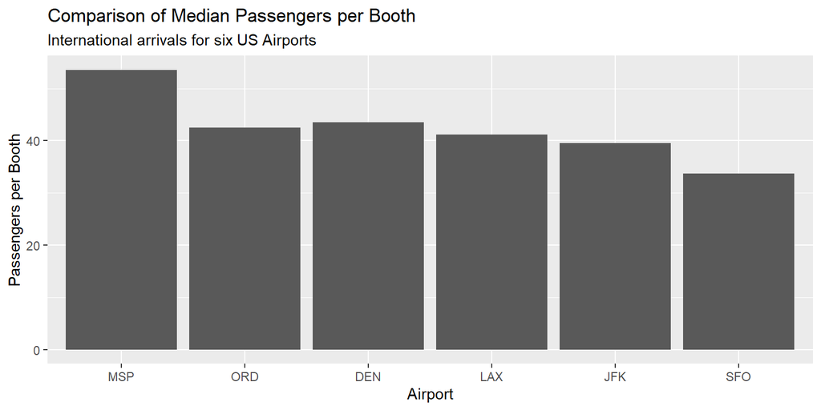

```r
ggplot(prob_1, aes(x = airport, y = median)) +
  geom_col() +
  xlab("Airport") +
  ylab("Passengers per Booth") +
  ggtitle("Comparison of Median Passengers per Booth",
          subtitle = "International arrivals for six US Airports")
```